# Case Study 2 Deliverable TAJAR

Tori Wheelis, Andy Ho, An Nguyen, Jodi Pafford, Rajat Chandna

8/4/2018

# Predicting And reducing Attrition Using Data Science

```r
# In order to import XLSX, we install the package "readxl" into our environment.  After loading library "readxl" we're able to use read_excel function to import the sheet "HR-employee-attrition Data" into a dataframe.
library(ggplot2)
library(readxl)
library(randomForest)
library(stringr)
library(plyr)
library(dplyr)
library(tidyr)
library(xlsx)
library(reshape2)
library(party)
library(gmodels)
library(vcd)
library(caret)
library(e1071)
library(tm)
library(SnowballC)
library(wordcloud)
library(RColorBrewer)
```

```r
attritionDF <- read_excel(path = "Attrition_Data_Clean.xlsx", sheet = "HR-employee-attrition Data")
```

## Introduction

Attrition, or voluntary employee turnover, comes as a high cost to companies. The cost of interviewing, training, productivity, and negative impacts on morale are just a few. The key to success for companies, then, is to attract and retain talent. To help facilitate talent management and reduce attrition, thereby reducing real cost to companies, DDSAnalytics’s in-house data science team, TAJAR, has compiled some important characteristics associated with increased risk of employee turnover. Our findings will allow companies to identify possible causes of employee turnover, create targeted approaches, and improve their talent management along with their company culture and profit margins.

DDSAnalytics is an analytics company that specializes in talent management solutions for Fortune 1000 companies. Talent management, broadly defined as the iterative process of developing and retaining employees, can include workforce planning, employee training programs, identifying high-potential employees and reducing/preventing voluntary employee turnover (attrition). DDSAnalytics has joined forces with TAJAR, their new in-house data science team, to apply data analysis to a dataset from IBM in order to help improve IBM’s attrition rate, and more broadly, the attrition rate of Fortune 1000 companies. This report gives a picture of the employees in the dataset, the top factors for attrition, and suggests targeted ways for companies to mitigate their attrition rates.

## Methodology

This data, obtained from IBM’s corporate office, allows a snapshot in to a large, thriving corporate company whose profit margins and general company culture could benefit from reducing attrition rates. After the data was cleaned and corrected for any formatting errors (since a few of the measures were self-reports from the employees), TAJAR reviewed the descriptive statistics. Then, TAJAR built a random forest model and edited it to identify the variables most strongly associated with attrition. After the initial findings, TAJAR continued to dig deeper and understand the “why” behind the numbers.

TAJAR used, in addition to some basic descriptive statistics, a random forest model to identify the most salient factors contributing to employee attrition.x

All of the code used to explore the data, including exploratory code not attached to this report, more details on the research methodology, and the data, as well a copy of this report, can be found online at https://github.com/R-Chandna/MSDS6306_CaseStudy_2.git.

```r
#1a The client wants this to be reproducible and know exactly what you did.  There needs to be an informative Readme, complete with several sections, as referenced in Live Session.  Give contact information, session Info, and the objective of the repo at least.
#1a: The README was updated to look pretty and have the basic introduction to everything.
#1b You have a large data set, and it needs its own Codebook, formatted in an approachable way.  Make sure you describe peculiarities of the data by variable and what needs transforming.  However, do not make it too long either.
#1b: The codebook was added as a separate file and to the README
#1c Create a file structure that is accessible and transparent.  Document it in the root directory, ideally in the Readme.
#1c: A clearly understandable directory was created and documented in the README
```

## Dataset Overview, Demographics

The dataset used came without any missing values, and required only a little cleaning, mostly renaming the variables to be more readable and workable, and changing the format of a few variables so the data imported cleanly.

```r
# 2A - a    Read the csv into R and take a look at the data set.  Output how many rows and columns the data.frame is.
# There are 1470 rows (observations) and 35 columns (variables)
dimDF <- dim(attritionDF)
names(dimDF) <- c("Rows", "Columns")
dimDF
```

```
##    Rows Columns
##    1470      35
```

```r
# 2B - b    The column names are either too much or not enough.  Change the column names so that they do not have spaces, underscores, slashes, and the like. All column names should be under 12 characters. Make sure youâre updating your codebook with information on the tidied data set as well.
# Results of column names and its string length count.
## Need to find a more elegant function to filter the list and subset only values greater than 12.  For now, this will suffice.
lettercount <- str_length(names(attritionDF))
countDF <- data.frame(cbind(names(attritionDF), lettercount))
names(countDF) <- c("Variable", "LetterCount")
countDF
```

```
##        Variable LetterCount
## 1           Age           3
## 2     Attrition           9
## 3    WorkTravel          10
## 4     DailyRate           9
## 5    Department          10
## 6  DistFromHome          12
## 7     Education           9
## 8  FieldOfStudy          12
## 9     Headcount           9
## 10   EmployeeID          10
## 11 EnvrSatIndex          12
## 12       Gender           6
## 13   HourlyRate          10
## 14    JobInvolv           9
```

[output cut: 21 more lines]

```r
# Replacing Original Variable names that have > 12 characters with new names under the Working column in Attrition_Col_Name_New.csv.

original <- names(attritionDF)
write.csv(original, "Attrition_Col_Name_Old.csv")
head(names(attritionDF))
```

```
## [1] "Age"          "Attrition"    "WorkTravel"   "DailyRate"
## [5] "Department"   "DistFromHome"
```

```r
colNamesDF <- read.csv("Attrition_Col_Name_New.csv")
working <- colNamesDF$Working
names(attritionDF) <- working
head(names(attritionDF))
```

```
## [1] "Age"          "Attrition"    "WorkTravel"   "DailyRate"
## [5] "Department"   "DistFromHome"
```

```r
# 2C - Due to Qualtrics, the following columns will have its integer value replaced by the definitions provided in the "Data Definitions" sheet.
## Will need to seperate the integer and characters into two seperate columns.
datadefDF <- read_excel ("CaseStudy2-data.xlsx", "Data Definitions")
datadefDF
```

```
## # A tibble: 34 x 2
##    Education               `1 'Below College'`
##    <chr>                   <chr>
##  1 <NA>                    2 'College'
##  2 <NA>                    3 'Bachelor'
##  3 <NA>                    4 'Master'
##  4 <NA>                    5 'Doctor'
##  5 <NA>                    <NA>
##  6 EnvironmentSatisfaction 1 'Low'
##  7 <NA>                    2 'Medium'
##  8 <NA>                    3 'High'
##  9 <NA>                    4 'Very High'
## 10 <NA>                    <NA>
## # ... with 24 more rows
```

```r
# 2D - d    Make sure your columns are the proper data types (i.e., numeric, character, etc.).  If they are incorrect, convert them.
# Verifying the columns class type are numeric and character.
as.matrix(lapply(attritionDF, class))
```

```
##              [,1]
## Age          "numeric"
## Attrition    "character"
## WorkTravel   "character"
## DailyRate    "numeric"
## Department   "character"
## DistFromHome "numeric"
## Education    "character"
## FieldOfStudy "character"
## Headcount    "numeric"
## EmployeeID   "numeric"
## EnvrSatIndex "character"
## Gender       "character"
## HourlyRate   "numeric"
## JobInvolv    "character"
## JobLevel     "numeric"
## JobRole      "character"
## JobSatIndex  "character"
## MaritalState "character"
## MonthlyInco  "numeric"
## MonthlyRate  "numeric"
## NumPriorComp "numeric"
## Over18       "character"
## OverTime     "character"
## PctSalaryInc "numeric"
## PerfRating   "character"
## RelpSatIndex "character"
## StdHours     "numeric"
## StockOptLvl  "numeric"
## TotWorkExp   "numeric"
## TrainedLstYr "numeric"
## WorkLifeFit  "character"
## YrsAtCompany "numeric"
## YrsInRole    "numeric"
## LastPromoted "numeric"
## YrsWithMgr   "numeric"
```

The dataset included information gathered on 1,470 employees who voluntarily filled out an online survey and had 35 variables that included whether or not they left the company (attrition), demographics such as age, gender, and marital status, as well as employee information such as job role, stock options, and compensation, and also included some other metrics, such as relationship, environment, and job satisfaction, etc. There is a codebook included with this report that details all 35 variables and their names as used in our code.

```r
table(attritionDF$Gender)
```

```
##
## Female   Male
##    588    882
```

```r
sort(unique(attritionDF$JobRole))
```

```
## [1] "Healthcare Representative" "Human Resources"
## [3] "Laboratory Technician"     "Manager"
## [5] "Manufacturing Director"    "Research Director"
## [7] "Research Scientist"        "Sales Executive"
## [9] "Sales Representative"
```

```r
table(attritionDF$Department)
```

```
##
##        Human Resources Research & Development                  Sales
##                     63                    961                    446
```

For privacy reasons, IBM and TAJAR with DDSAnalytics did not want to run any analyses on minors. There were, however, no minors in the dataset. The age of the participating employees ranged from 18-60.

```r
#3a -   Remove all observations where the participant is under age 18.  No further analysis of underage individuals is permitted by your client.  Remove any other age outliers as you see fit, but be sure to tell what youâre doing and why.
# Age between 18 and 60, no children under 18 and no obvious age outliers.
summary(attritionDF$Age)
```

```
##    Min. 1st Qu.  Median    Mean 3rd Qu.    Max.
##   18.00   30.00   36.00   36.92   43.00   60.00
```

```r
attritionDF$Over18[attritionDF$Over18 == 'N']
```

```
## character(0)
```

Of the employees, 882 were male and 588 were female. The job roles listed were Healthcare Representative, Human Resources, Laboratory Technician, Manager, Manufacturing Director, Research Director, Research Scientist, Sales Executive, and Sales Represantative spread across Human Resources with 63 employees, Research & Development with 961 employees, and Sales with 446 employees. Of Human Resource’s 63 employees, 11 were managers. Of R&D’s 961, 54 were managers, and of Sales’ 446, 37 were managers.

```r
#3c. Give the frequencies (in table format or similar) for Gender, Education, and Occupation.  They can be separate tables, if that's your choice.
gendertable <- table(attritionDF$Gender)
gendertable
```

```
##
## Female   Male
##    588    882
```

```r
educationtable <- table(attritionDF$Education)
educationtable
```

```
##
##      Bachelor Below College       College        Doctor        Master
##           572           170           282            48           398
```

```r
occupationtable <- table(attritionDF$JobRole)
occupationtable
```

```
##
## Healthcare Representative           Human Resources
##                       131                        52
##     Laboratory Technician                   Manager
##                       259                       102
##    Manufacturing Director         Research Director
##                       145                        80
##        Research Scientist           Sales Executive
##                       292                       326
##      Sales Representative
##                        83
```

```r
#3d. Give the counts (again, table) of management positions.
#all the counts of all the positions (for comparison)
management <- count(attritionDF, Department, JobRole)
management
```

```
## # A tibble: 11 x 3
##    Department             JobRole                       n
##    <chr>                  <chr>                     <int>
##  1 Human Resources        Human Resources              52
##  2 Human Resources        Manager                      11
##  3 Research & Development Healthcare Representative   131
##  4 Research & Development Laboratory Technician       259
##  5 Research & Development Manager                      54
##  6 Research & Development Manufacturing Director      145
##  7 Research & Development Research Director            80
##  8 Research & Development Research Scientist          292
##  9 Sales                  Manager                      37
## 10 Sales                  Sales Executive             326
## 11 Sales                  Sales Representative         83
```

```r
#just the manager positions
filter(management, JobRole=="Manager")
```

```
## # A tibble: 3 x 3
##   Department             JobRole     n
##   <chr>                  <chr>   <int>
## 1 Human Resources        Manager    11
## 2 Research & Development Manager    54
## 3 Sales                  Manager    37
```

```r
#3b - b Please provide (in table format or similar), descriptive statistics on at least 7 variables (age, Income, etc.).  Create a simple histogram for two of them.  Comment on the shape of the distribution in your markdown.
# Create a table of summary statistics of Variables with numerical values
SummaryStat <- matrix(ncol = 6, nrow = 0)
SummaryStat <- rbind(SummaryStat, summary(attritionDF$MonthlyInco))
SummaryStat <- rbind(SummaryStat, summary(attritionDF$Age))
SummaryStat <- rbind(SummaryStat, summary(attritionDF$DistFromHome))
SummaryStat <- rbind(SummaryStat, summary(attritionDF$PctSalaryInc))
SummaryStat <- rbind(SummaryStat, summary(attritionDF$TotWorkExp))
SummaryStat <- rbind(SummaryStat, summary(attritionDF$YrsAtCompany))
SummaryStat <- rbind(SummaryStat, summary(attritionDF$NumPriorComp))
SummaryStat <- as.data.frame(SummaryStat)
row.names(SummaryStat) <- c("MonthlyInco", "Age", "DistFromHome", "PctSalarInc", "TotWorkExp", "YrsAtCompany", "NumPriorComp")
SummaryStat
```

```
##              Min. 1st Qu. Median        Mean 3rd Qu.  Max.
## MonthlyInco  1009    2911   4919 6502.931293    8379 19999
## Age            18      30     36   36.923810      43    60
## DistFromHome    1       2      7    9.192517      14    29
## PctSalarInc    11      12     14   15.209524      18    25
## TotWorkExp      0       6     10   11.279592      15    40
## YrsAtCompany    0       3      5    7.008163       9    40
## NumPriorComp    0       1      2    2.693197       4     9
```

Out of the 1470 employees, 237 voluntarily left the company, or roughly 16%. The department with the most employees who left was the the Sales department with ~20.6% attrition rate followed by Human Resources with ~19.0% and R&D with ~13.8%. There were notable spikes in attrition for employees aged 18-21 and for employees who made less than 30,000 dollars a year, or 2,500 dollars a month. However, there seemed to be no significant difference in attrition according to gender or distance from home.

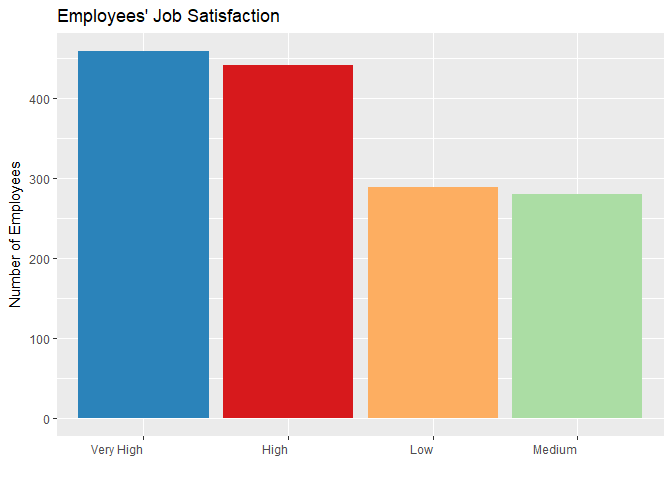

```r
#Create table with summary of variables with categorial variables, using first two factors most likely to attribute to attrition
JobSatTable <- as.data.frame(table(attritionDF$JobSatIndex))
JobSatTable <- data.frame(JobSatTable[,-1], row.names = JobSatTable[,1])
colnames(JobSatTable) <- c("Freq")

#Barplot of Job Satisfaction Level
ggplot(JobSatTable, aes(reorder(x=row.names(JobSatTable), -Freq), y=Freq)) + geom_bar(stat = "identity", aes(fill = row.names(JobSatTable))) + labs(title = "Employees' Job Satisfaction", y = "Number of Employees", x = "") + theme(axis.text.x = element_text(angle = 0, hjust = 1), legend.position="none") + scale_fill_brewer(palette="Spectral")
```

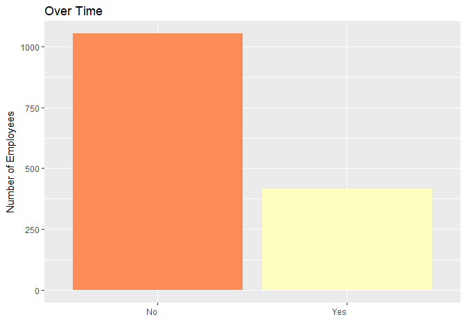

```r
OverTimeTable <- as.data.frame(table(attritionDF$OverTime))
OverTimeTable <- data.frame(OverTimeTable[,-1], row.names = OverTimeTable[,1])
colnames(OverTimeTable) <- c("Freq")

#Barplot of Over Time
ggplot(OverTimeTable, aes(reorder(x=row.names(OverTimeTable), -Freq), y=Freq)) + geom_bar(stat = "identity", aes(fill = row.names(OverTimeTable))) + labs(title = "Over Time", y = "Number of Employees", x = "") + theme(axis.text.x = element_text(angle = 0, hjust = 1), legend.position="none") + scale_fill_brewer(palette="Spectral")
```

```r
table(attritionDF$Attrition)
```

```
##
##   No  Yes
## 1233  237
```

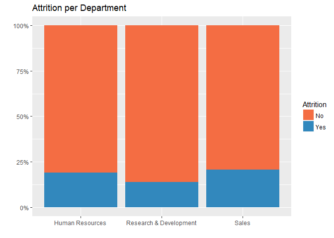

```r
#Department
ggplot(attritionDF, aes(x = Department, fill = Attrition)) + geom_bar(position = "fill") + labs(title = "Attrition per Department", x = "", y = "", color = "") + scale_y_continuous(labels = scales::percent) + scale_fill_manual(values=c(brewer.pal(11, "Spectral")[3], brewer.pal(11, "Spectral")[10]))
```

```r
tempDF <- attritionDF[,c("Attrition","Department")]
table(melt(tempDF))
```

```
##          Department
## Attrition Human Resources Research & Development Sales
##       No               51                    828   354
##       Yes              12                    133    92
```

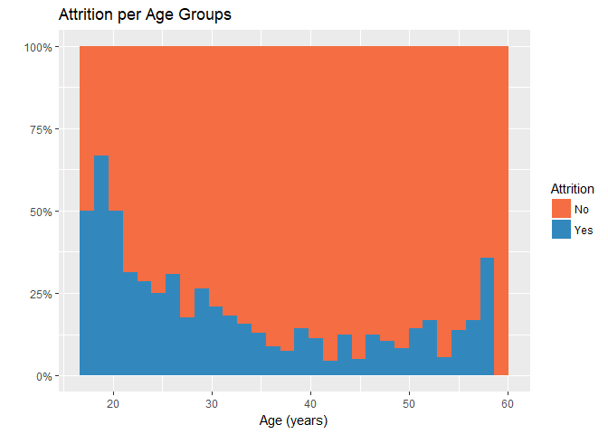

```r
#Age
ggplot(attritionDF, aes(x = Age, fill = Attrition)) + geom_histogram(position = "fill") + labs(title = "Attrition per Age Groups", x = "Age (years)", y = "", color = "") + scale_y_continuous(labels = scales::percent) + scale_fill_manual(values=c(brewer.pal(11, "Spectral")[3], brewer.pal(11, "Spectral")[10]))
```

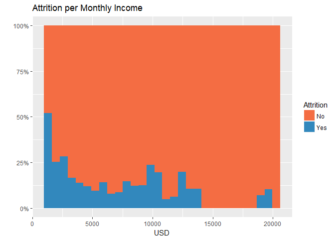

```r
#Income
ggplot(attritionDF, aes(x = MonthlyInco, fill = Attrition)) + geom_histogram(position = "fill") + labs(title = "Attrition per Monthly Income", x = "USD", y = "", color = "") + scale_y_continuous(labels = scales::percent) + scale_fill_manual(values=c(brewer.pal(11, "Spectral")[3], brewer.pal(11, "Spectral")[10]))
```

## Deeper Analysis

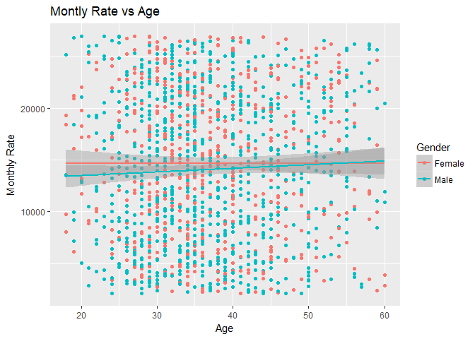

```r
#An's code for Q4b
library(RColorBrewer)

#4b there seemed to be no relationship between age and MonthlyRate, DailyRate, or HourlyRate
##Monthly Rate
ggplot(data = attritionDF, aes(x = Age, y = MonthlyRate)) + geom_point(aes(colour = factor(Gender))) + geom_smooth(method = "lm", aes(group = Gender, colour = Gender)) + labs(title = "Montly Rate vs Age", x = "Age", y = "Monthly Rate", color = "Gender")
```

```r
test <- lm(attritionDF$MonthlyRate ~ attritionDF$Age)
summary(test)
```

```
##
## Call:
## lm(formula = attritionDF$MonthlyRate ~ attritionDF$Age)
##
## Residuals:
##    Min     1Q Median     3Q    Max
## -12452  -6193    -45   6111  13056
##
## Coefficients:
##                 Estimate Std. Error t value Pr(>|t|)
## (Intercept)     13506.10     773.19  17.468   <2e-16 ***
## attritionDF$Age    21.86      20.33   1.075    0.282
## ---
## Signif. codes:  0 '***' 0.001 '**' 0.01 '*' 0.05 '.' 0.1 ' ' 1
##
## Residual standard error: 7117 on 1468 degrees of freedom
## Multiple R-squared:  0.0007869,  Adjusted R-squared:  0.0001062
## F-statistic: 1.156 on 1 and 1468 DF,  p-value: 0.2825
```

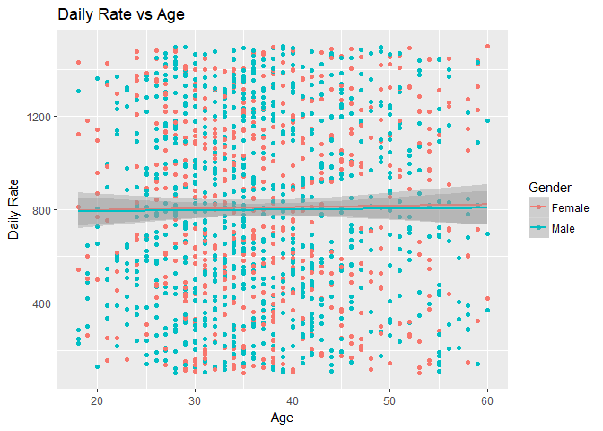

```r
##Daily Rate
ggplot(data = attritionDF, aes(x = Age, y = DailyRate)) + geom_point(aes(colour = factor(Gender))) + geom_smooth(method = "lm", aes(group = Gender, colour = Gender)) + labs(title = "Daily Rate vs Age", x = "Age", y = "Daily Rate", color = "Gender")
```

```r
test <- lm(attritionDF$DailyRate ~ attritionDF$Age)
summary(test)
```

```
##
## Call:
## lm(formula = attritionDF$DailyRate ~ attritionDF$Age)
##
## Residuals:
##     Min      1Q  Median      3Q     Max
## -708.06 -337.55   -0.61  355.66  697.72
##
## Coefficients:
##                 Estimate Std. Error t value Pr(>|t|)
## (Intercept)     785.0985    43.8469  17.905   <2e-16 ***
## attritionDF$Age   0.4709     1.1528   0.408    0.683
## ---
## Signif. codes:  0 '***' 0.001 '**' 0.01 '*' 0.05 '.' 0.1 ' ' 1
##
## Residual standard error: 403.6 on 1468 degrees of freedom
## Multiple R-squared:  0.0001137,  Adjusted R-squared:  -0.0005675
## F-statistic: 0.1669 on 1 and 1468 DF,  p-value: 0.683
```

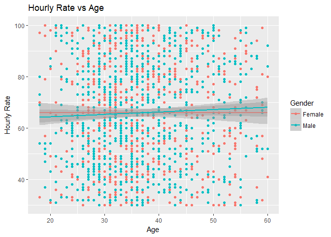

```r
##Hourly Rate
ggplot(data = attritionDF, aes(x = Age, y = HourlyRate)) + geom_point(aes(colour = factor(Gender))) + geom_smooth(method = "lm", aes(group = Gender, colour = Gender)) + labs(title = "Hourly Rate vs Age", x = "Age", y = "Hourly Rate", color = "Gender")
```

```r
test <- lm(attritionDF$HourlyRate ~ attritionDF$Age)
summary(test)
```

```
##
## Call:
## lm(formula = attritionDF$HourlyRate ~ attritionDF$Age)
##
## Residuals:
##     Min      1Q  Median      3Q     Max
## -36.868 -17.517   0.064  17.483  35.078
##
## Coefficients:
##                 Estimate Std. Error t value Pr(>|t|)
## (Intercept)     63.89557    2.20855  28.931   <2e-16 ***
## attritionDF$Age  0.05405    0.05806   0.931    0.352
## ---
## Signif. codes:  0 '***' 0.001 '**' 0.01 '*' 0.05 '.' 0.1 ' ' 1
##
## Residual standard error: 20.33 on 1468 degrees of freedom
## Multiple R-squared:  0.0005898,  Adjusted R-squared:  -9.096e-05
## F-statistic: 0.8664 on 1 and 1468 DF,  p-value: 0.3521
```

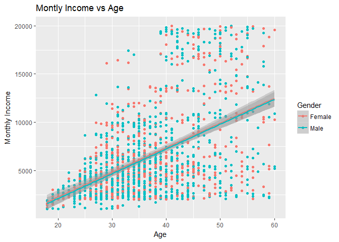

```r
#4b. MonthlyInco shows correlation with Age.  Tried linear regression on untransformed data and log, reciprocal, square root transformations
## untransformed
ggplot(data = attritionDF, aes(x = Age, y = MonthlyInco)) + geom_point(aes(colour = Gender)) + geom_smooth(method = 'lm', aes(group = Gender, colour = Gender)) + labs(title = "Montly Income vs Age", x = "Age", y = "Monthly Income", color = "Gender")
```